# Advanced Bioinformatics 2023 assessment

m1903050

2023-04-18

## R Markdown: General R/Rstudio assessment

Task 3.1 Using the sum() function and : operator, write an expression in the code snippet to evaluate the sum of all integers between 5 and 55. (4pt)

```r
sum(5:55)
```

```
## [1] 1530
```

Task 3.2 Write a function called sumfun with one input parameter, called n, that calculates the sum of all integers between 5 and n. Use the function to do the calculation for n = 10, n = 20, and n = 100 and present the results. (4pt)

```r
sumfun <- function(n)
  {sum(5:n)}

sumfun(10)
```

```
## [1] 45
```

```r
sumfun(20)
```

```
## [1] 200
```

```r
sumfun(100)
```

```
## [1] 5040
```

Task 3.3 The famous Fibonacci series is calculated as the sum of the two preceding members of the sequence, where the first two steps in the sequence are 1, 1. Write an R script using a for loop to calculate and print out the first 12 entries of the Fibonacci series. (4pt)

```r
n <- 12

fibonacci <- numeric(n)
fibonacci[1] <- 1
fibonacci[2] <- 1

for (f in 3:n)
  fibonacci[f] <- fibonacci[f-1]+fibonacci[f-2]

print(fibonacci)
```

```
##  [1]   1   1   2   3   5   8  13  21  34  55  89 144
```

Task 3.4 With the mtcars data set bundled with R, use ggplot to generate a box of miles per gallon (in the variable mpg) as a function of the number of gears (in the variable gear). Use the fill aesthetic to color bars by number of gears. (4pt)

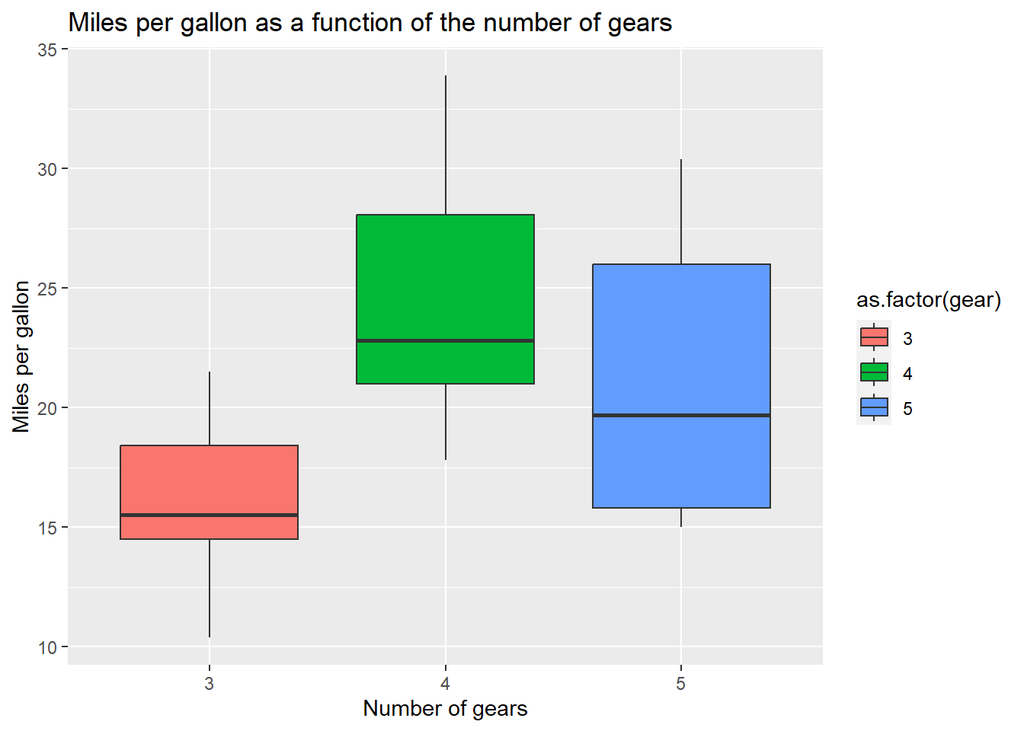

```r
library(ggplot2)
ggplot(mtcars, aes(x= as.factor(gear),y=mpg))+
  geom_boxplot(aes(fill=as.factor(gear)))+
  labs(title="Miles per gallon as a function of the number of gears", x="Number of gears", y="Miles per gallon")
```

Task 3.5 Using the cars dataset and the function lm, fit a linear relationship between speed and breaking distance in the variable distance. What are the fitted slope and intercept of the line, and their standard errors? What are the units used for the variables in the dataset? (4pt)

```r
#The head command was used to determine and explore the data set with its corresponding variables.
head(cars, 5)
```

```
##   speed dist
## 1     4    2
## 2     4   10
## 3     7    4
## 4     7   22
## 5     8   16
```

```r
#The linear_model variable is created from the lm function of the distance proportional to the speed.
linear_model <- lm(formula = dist ~ speed, data=cars)


#This line provides the summary of the coefficients in the linear_model variable.
summary(linear_model)$coefficients
```

```
##               Estimate Std. Error   t value     Pr(>|t|)
## (Intercept) -17.579095  6.7584402 -2.601058 1.231882e-02
## speed         3.932409  0.4155128  9.463990 1.489836e-12
```

```r
#The Y intercept of the line has a value of -17.579095 whereas the fitted slope of the breaking distance has a value of 3.932409.
#The standard error for the Y intercept is 6.7584402 whereas the fitted slope of the breaking distance has a standard error value of 0.4155128.
#The units for the speed variable is in miles per hour (mph) whereas the units used for the breaking distant variable is in feet (ft).
```

Task 3.6 Use ggplot to plot the data points from Task 6 and the linear fit. (4pt)

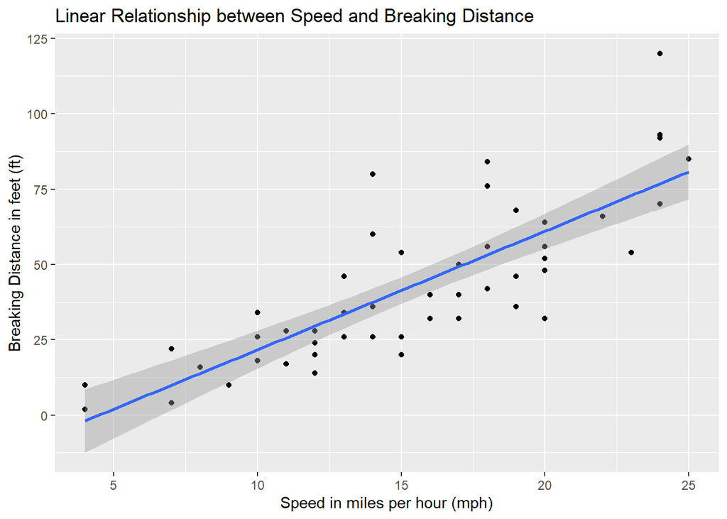

```r
ggplot(cars, aes(x = speed, y=dist))+
  geom_point()+
  geom_smooth(method = "lm")+
  labs(title="Linear Relationship between Speed and Breaking Distance",
       x="Speed in miles per hour (mph)",
       y="Breaking Distance in feet (ft)")
```

Task 3.7 Again using the cars dataset, now use linear regression (lm) to estimate the average reaction time for the driver to start breaking (in seconds). To simplify matters you may assume that once breaking commences, breaking distance is proportional to the square of the speed. Explain the steps in your analysis. Do you get reasonable results? Finally, use ggplot to plot the data points and the fitted relationship. (9pt)

```r
# 1 feet = 0.000189394 mile; the stopping distance is multiplied by 0.000189394 to convert the stopping distant variables to miles.
Stopping_distance_mil <- cars$dist*0.000189394
Stopping_distance_mil
```

```
##  [1] 0.000378788 0.001893940 0.000757576 0.004166668 0.003030304 0.001893940
##  [7] 0.003409092 0.004924244 0.006439396 0.003219698 0.005303032 0.002651516
## [13] 0.003787880 0.004545456 0.005303032 0.004924244 0.006439396 0.006439396
## [19] 0.008712124 0.004924244 0.006818184 0.011363640 0.015151520 0.003787880
## [25] 0.004924244 0.010227276 0.006060608 0.007575760 0.006060608 0.007575760
## [31] 0.009469700 0.007954548 0.010606064 0.014393944 0.015909096 0.006818184
## [37] 0.008712124 0.012878792 0.006060608 0.009090912 0.009848488 0.010606064
## [43] 0.012121216 0.012500004 0.010227276 0.013257580 0.017424248 0.017613642
## [49] 0.022727280 0.016098490
```